# Introduction to R

Ben Marconi

February 18, 2020

Introduction to R Studio and Analysis/Plotting in R

What do the different windows do/mean?

Basic R Commands

```r
10^3
```

```
## [1] 1000
```

```r
(2020-2012)/(2020-1994)
```

```
## [1] 0.3076923
```

Variable names must start with a letter. Naming Variables a user call and manipulate them later

```r
percent_of_life_as_academic_slave = (2020-2012)/(2020-1994)
x = percent_of_life_as_academic_slave
```

Simple arithmetic in R can be perfomred as follows using +,-,*,/,%%.%/%

```r
x*2
```

```
## [1] 0.6153846
```

```r
x=5
y=10

x-y
```

```
## [1] -5
```

```r
x*y
```

```
## [1] 50
```

```r
y/x
```

```
## [1] 2
```

```r
y%%x #Modulus (remainder from division)
```

```
## [1] 0
```

```r
y%/%x #Interger division
```

```
## [1] 2
```

Relational Operators: </>/<=/>=/!=/== can be used to compare values of variables

```r
x=5
y=16

x<y
```

```
## [1] TRUE
```

```r
x>y
```

```
## [1] FALSE
```

```r
x<=y
```

```
## [1] TRUE
```

```r
y>=17
```

```
## [1] FALSE
```

```r
y==16
```

```
## [1] TRUE
```

```r
x!=5
```

```
## [1] FALSE
```

Getting Sendy with Vectors: Creating short vectors can be accomplished by concatenating integers and numerics.

```r
x = c(2,6,3)
y = c(6,4,2)

x+y #operations occur element-wise
```

```
## [1]  8 10  5
```

```r
x <- c(2,1,8,3)
y <- c(9,4)
x+y #recycling occurs
```

```
## [1] 11  5 17  7
```

```r
x-1
```

```
## [1] 1 0 7 2
```

```r
x + c(1,2,3) #no way to recycle, longer vecotr is not intergal multiple of shorter vector
```

```
## [1]  3  3 11  4
```

```r
rm(list=ls()) #clears active environment of variables
```

Setting a Working Directory: Choose a folder where data is saved and r scripts can be written with setwd().

```r
setwd("~/Utah PhD/3rd Year/Spring 2020/R Group/intro_activity")
```

Setting Up a Session for Analysis: install.packages() loads packages not already loaded in base-R to increase the language’s functionality. Once a package is installed, calling the package with require() or library() loads the package’s data for use.

```r
require(stats)
require(graphics)
require(ggplot2)
```

Some data has already been loaded into R for us. Most of these datasets are clean and behave nicely for example analyses. Data() will pull up a page where you can view the datasets available in R.

```r
data() #explore preloaded datasets in R
data("faithful")
faithful
```

```
##     eruptions waiting
## 1       3.600      79
## 2       1.800      54
## 3       3.333      74
## 4       2.283      62
## 5       4.533      85
## 6       2.883      55
## 7       4.700      88
## 8       3.600      85
## 9       1.950      51
## 10      4.350      85
## 11      1.833      54
## 12      3.917      84
## 13      4.200      78
## 14      1.750      47
```

[output cut: 258 more lines]

Using the head() function is useful, as it gives you a preview of the dataset without showing (unreasonably in this the case) the entire data frame.

```r
head(faithful)
```

```
##   eruptions waiting
## 1     3.600      79
## 2     1.800      54
## 3     3.333      74
## 4     2.283      62
## 5     4.533      85
## 6     2.883      55
```

```r
summary(faithful)
```

```
##    eruptions        waiting
##  Min.   :1.600   Min.   :43.0
##  1st Qu.:2.163   1st Qu.:58.0
##  Median :4.000   Median :76.0
##  Mean   :3.488   Mean   :70.9
##  3rd Qu.:4.454   3rd Qu.:82.0
##  Max.   :5.100   Max.   :96.0
```

The $ can be used to select a column of data within a data frame (the naming convention for how R stores data in a table)

```r
duration = faithful$eruptions
range(duration)
```

```
## [1] 1.6 5.1
```

```r
mean(duration)
```

```
## [1] 3.487783
```

Let’s do some simple organization of the data with the seq() function to break the data into cleaner intervals.

```r
breaks = seq(1.5, 5.5, by = 0.5) #organizing the data into sequence by interval of 0.5
breaks
```

```
## [1] 1.5 2.0 2.5 3.0 3.5 4.0 4.5 5.0 5.5
```

```r
duration.cut = cut(duration, breaks, right = FALSE) #this classifies the eruptions by interval - FALSE sets intervals closed on left, open on right
duration.frequency = table(duration.cut) #calculate freq of eruption in each sub-interval
duration.frequency
```

```
## duration.cut
## [1.5,2) [2,2.5) [2.5,3) [3,3.5) [3.5,4) [4,4.5) [4.5,5) [5,5.5)
##      51      41       5       7      30      73      61       4
```

```r
cbind(duration.frequency) #creates a column from table
```

```
##         duration.frequency
## [1.5,2)                 51
## [2,2.5)                 41
## [2.5,3)                  5
## [3,3.5)                  7
## [3.5,4)                 30
## [4,4.5)                 73
## [4.5,5)                 61
## [5,5.5)                  4
```

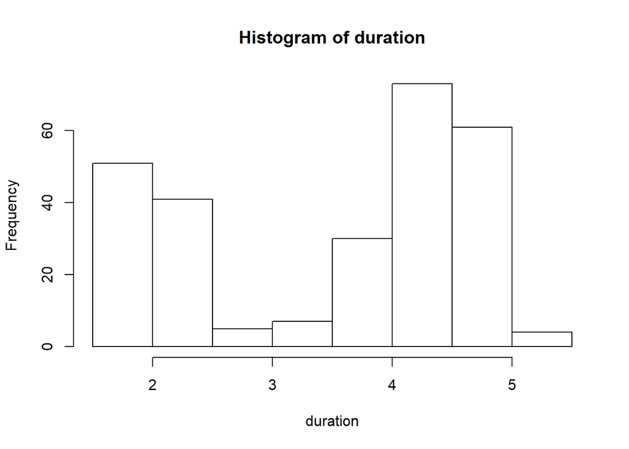

```r
duration = faithful$eruptions

#Make a PLot
hist(duration, right=FALSE)
```

```r
colors = c("red", "yellow", "green", "violet", "orange")

waiting = faithful$waiting
head(cbind(duration,waiting)) #Pair eruptions and waiting values to match (x,y) coord
```

```
##      duration waiting
## [1,]    3.600      79
## [2,]    1.800      54
## [3,]    3.333      74
## [4,]    2.283      62
## [5,]    4.533      85
## [6,]    2.883      55
```

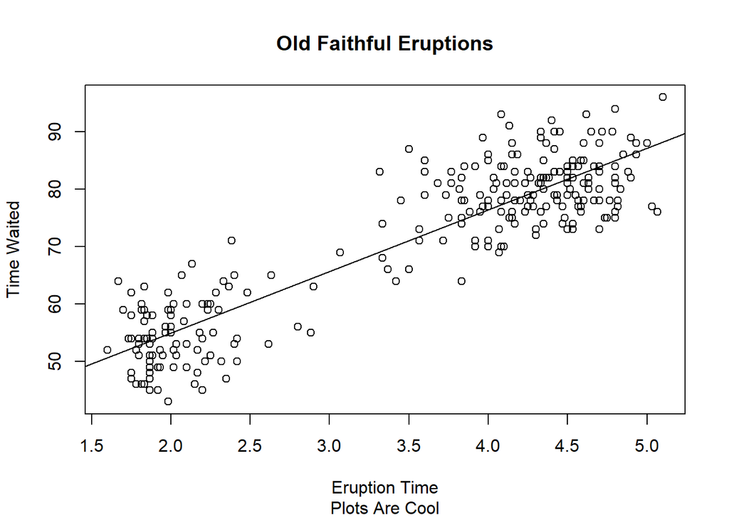

```r
plot(duration, waiting,
     xlab = "Eruption Time",
     ylab = "Time Waited",
     main = "Old Faithful Eruptions",
     sub= "Plots Are Cool")
abline(lm(waiting ~ duration))
```

```r
fit = lm(waiting ~ duration)
summary(fit)
```

```
##
## Call:
## lm(formula = waiting ~ duration)
##
## Residuals:
##      Min       1Q   Median       3Q      Max
## -12.0796  -4.4831   0.2122   3.9246  15.9719
##
## Coefficients:
##             Estimate Std. Error t value Pr(>|t|)
## (Intercept)  33.4744     1.1549   28.98   <2e-16 ***
## duration     10.7296     0.3148   34.09   <2e-16 ***
## ---
## Signif. codes:  0 '***' 0.001 '**' 0.01 '*' 0.05 '.' 0.1 ' ' 1
##
## Residual standard error: 5.914 on 270 degrees of freedom
## Multiple R-squared:  0.8115, Adjusted R-squared:  0.8108
## F-statistic:  1162 on 1 and 270 DF,  p-value: < 2.2e-16
```

```r
##Descriptive Statistics
#Hmisc
#pastecs
#psych (uses grouping variable as organizational metric)
#doBy

##LEleL uP KiDdOs
setwd("~/Utah PhD/3rd Year/Spring 2020/R Group/intro_activity/Rgraphics/dataSets")
install.packages("tidyverse")
library(tidyverse)
housing = read.csv("landdata-states.csv")
head(housing[1:5]) #returns columns 1-5
```

```
##   State region    Date Home.Value Structure.Cost
## 1    AK   West 2010.25     224952         160599
## 2    AK   West 2010.50     225511         160252
## 3    AK   West 2009.75     225820         163791
## 4    AK   West 2010.00     224994         161787
## 5    AK   West 2008.00     234590         155400
## 6    AK   West 2008.25     233714         157458
```

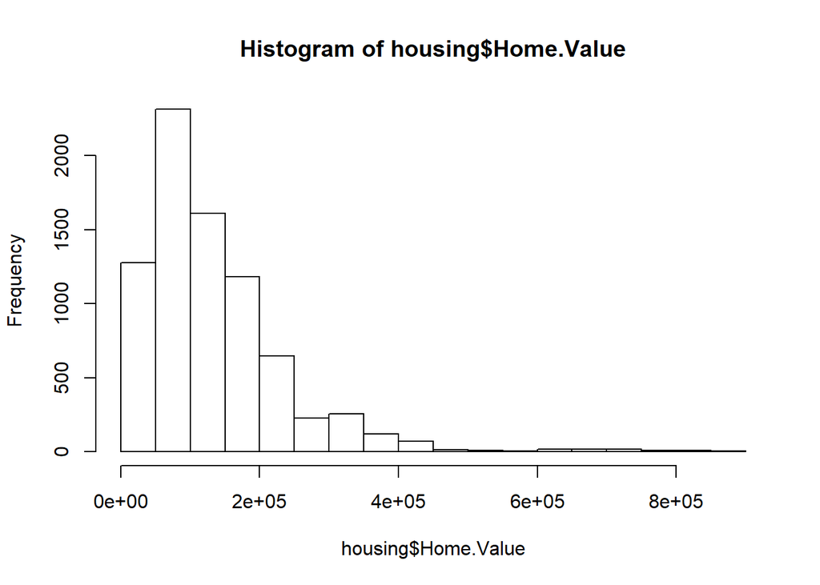

```r
#Histogram
hist(housing$Home.Value)
```

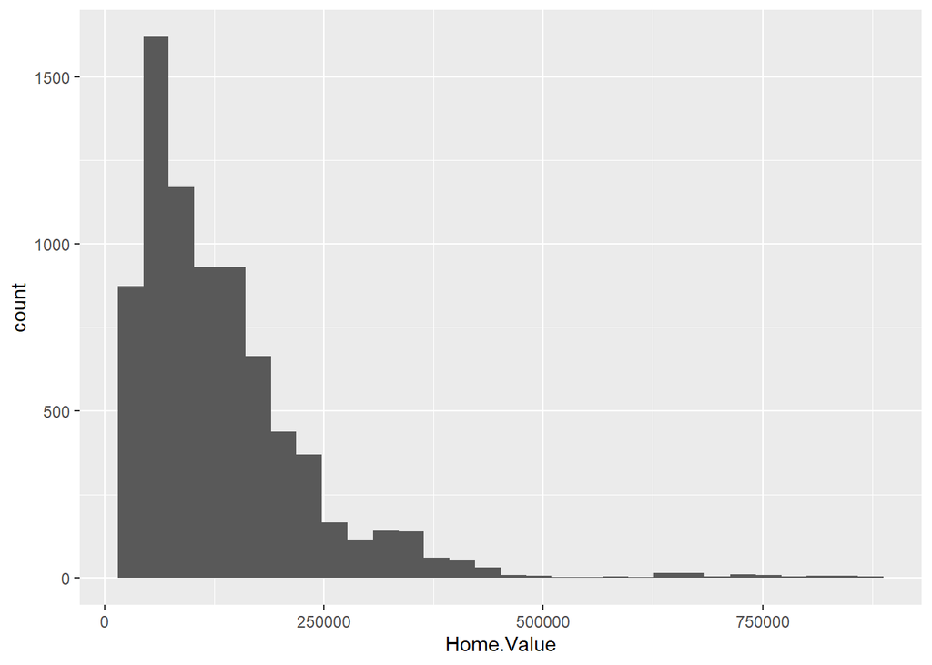

```r
library(ggplot2)
ggplot(housing, aes(x = Home.Value)) +
  geom_histogram()
```

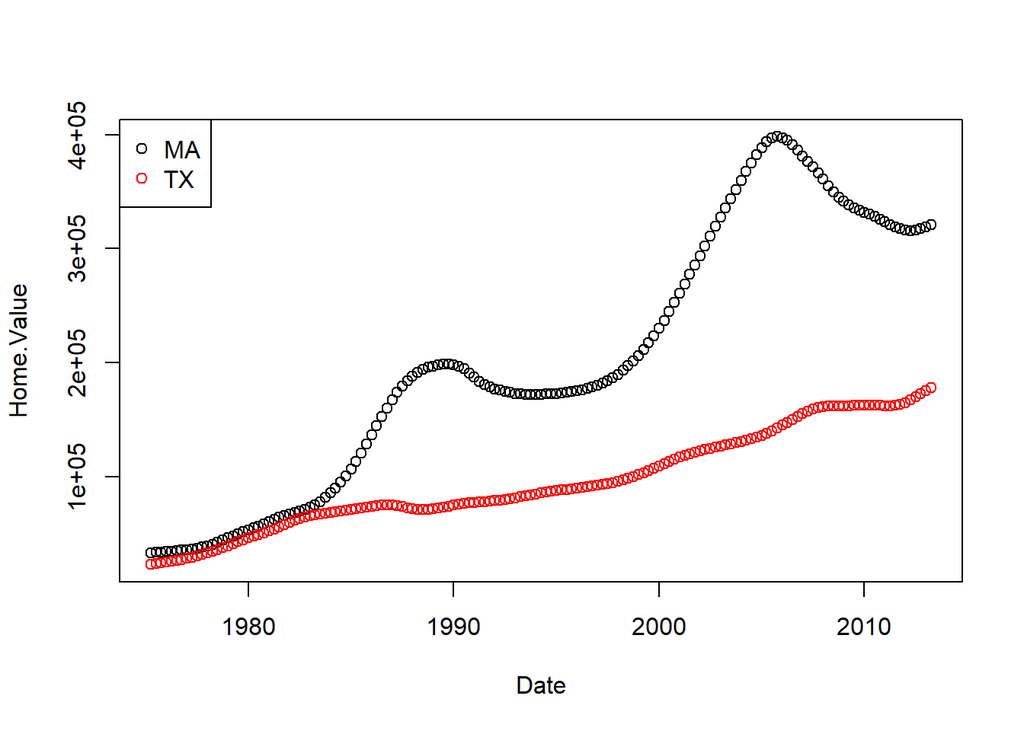

```r
plot(Home.Value ~ Date,
     col = factor(State),
     data = filter(housing, State %in% c("MA", "TX")))
legend("topleft",
       legend = c("MA", "TX"),
       col = c("black", "red"),
       pch = 1)
```

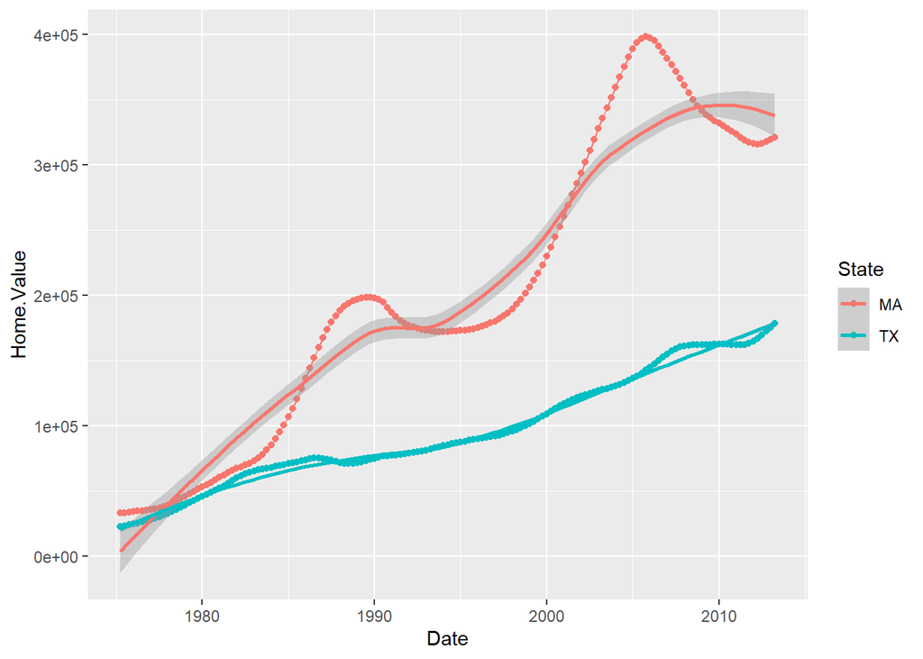

```r
ggplot(filter(housing, State %in% c("MA", "TX")),
       aes(x=Date,
           y=Home.Value,
           color=State))+
  geom_point()+
  geom_line()+
  geom_smooth()
```